# article

**Efficacy of Biological and Chemical Control Agents Against the Potato Psyllid (*Bactericera cockerelli* Šulc) Under Field Conditions**

Gabriela Cárdenas-Huamán<sup>1</sup>; Henry Morocho-Romero<sup>1</sup>; Sebastian Casas-Niño<sup>1</sup>; Sandy Vilchez-Navarro<sup>1</sup>; Leslie D. Velarde-Apaza<sup>1</sup>; Max Ramirez-Rojas<sup>1</sup>; Juancarlos Cruz<sup>1</sup>; Flavio Lozano-Isla<sup>1,2*</sup>

*<sup>1</sup>.Dirección de Servicios Estratégicos Agrarios, Estación Experimental Agraria El Chira, Instituto Nacional de Innovación Agraria (INIA), Carretera Sullana—Talara Km. 1027, Piura 20120, Perú*

*<sup>2</sup> Facultad de Ingeniería y Ciencias Agrarias, Universidad Nacional Toribio Rodríguez de Mendoza de Amazonas (UNTRM), Chachapoyas, Perú.*

* Corresponding author: *flavio.lozano@untrm.edu.pe*

| **Author** | **ORCID** | **Email** |
| --- | --- | --- |
| Gabriela Cárdenas-Huamán | 0000-0002-8379-5464 | 20200607@lamolina.edu.pe |
| Henry Morocho-Romero | 0000-0002-1520-2372 | 0202018122@alumnos.unp.edu.pe |
| Sebastian Casas-Niño | 0000-0002-6576-8761 | 20140231@lamolina.edu.pe |
| Sandy Vilchez-Navarro | 0009-0002-1784-5563 | 0202018140@alumnos.unp.edu.p |
| Leslie Diana Velarde-Apaza | 0000-0001-6031-6355 | leslie.velarde@upn.pe |
| Max Ramirez-Rojas | 0000-0003-3322-0838 | proyectochira@inia.gob.pe |
| Juancarlos Cruz | 0009-0005-8288-2768 | jcruz@inia.gob.pe |
| Flavio Lozano-Isla | 0000-0002-0714-669X | flavio.lozano@untrm.edu.pe |

**Highlights**

**ABSTRACT**

**Keywords:** Andean agriculture; entomopathogenic fungi; integrated pest management; *Candidatus Liberibacter solanacearum*; field trials; tuber yield; zebra chip disease

# 1 INTRODUCTION

Potato (*Solanum tuberosum L.; Solanales: Solanaceae)* is currently the third most important food crop worldwide [[1,2]](https://www.zotero.org/google-docs/?Mh7zGB). It originated in the Andes of South America, particularly between the regions of Peru and Bolivia, where it was domesticated approximately 7,000 to 10,000 years ago [[3–5]](https://www.zotero.org/google-docs/?5mF91J). This center of origin harbors an extraordinary diversity of native potato genotypes, underscoring their cultural and genetic significance to global agriculture [[6]](https://www.zotero.org/google-docs/?oPXwTH). Over time, potato cultivation has diversified into more than 4,000 edible varieties, largely as a result of clonal propagation through tubers. This reproductive strategy has contributed to a substantial expansion of its genome, particularly in resistance-related genes compared with sexually propagated Solanaceae crops [[7,8]](https://www.zotero.org/google-docs/?wTwoy2).

The potato psyllid, *Bactericera cockerell*i (Šulc) (Hemiptera: Triozidae), is an oligophagous insect widely distributed across cultivated and natural habitats, feeding mainly on solanaceous hosts [[9–11]](https://www.zotero.org/google-docs/?mowINC). Native to North America [[12]](https://www.zotero.org/google-docs/?qLmdUZ), the pest has progressively expanded its distribution to Central America and parts of Europe [[13]](https://www.zotero.org/google-docs/?iLeMan), successfully adapting to semi-arid and temperate climates [[14,15]](https://www.zotero.org/google-docs/?gJOWqW). In Peru, *B. cockerelli* has been established since 2021, with damage reports dating back to 2019 in the province of Huancabamba [[16]](https://www.zotero.org/google-docs/?hAKRFR). Both nymphs and adults are responsible for transmitting *Candidatus Liberibacter solanacearum* (CLso) [[17]](https://www.zotero.org/google-docs/?rGhsso), the causal agent of the economically important disease complex known as zebra chip (ZC) [[4,10,11]](https://www.zotero.org/google-docs/?euC7YX). CLso infection directly affects phloem tissues, reducing yields by 35–40% and compromising marketable quality through necrotic streaks, vascular discoloration, and abnormal sprouting, rendering tubers unfit for commercialization [[11,18]](https://www.zotero.org/google-docs/?f33bNo).

As *S. tuberosum* serves as a primary host for *B. cockerelli,* its genetic resources face a critical threat from the purple-top complex, which is caused by CLso and transmitted by this psyllid, also known as the tomato–potato psyllid [[19]](https://www.zotero.org/google-docs/?w63LoD). The disease is characterized by apical chlorosis, foliar reddening or purpling, stunted growth, and internal tuber deformities, often associated with zebra chip symptoms that reduce the commercial value of the crop [[20]](https://www.zotero.org/google-docs/?isOXfz).

In addition to biotic stressors, abiotic factors such as drought also exacerbate potato susceptibility to pest infestation. Water stress significantly impairs plant defense capacity and disrupts nutrient balance [[17,21]](https://www.zotero.org/google-docs/?xWkdl2). In tomato plants subjected to moderate water stress, increased susceptibility to *B. cockerelli* colonization was observed, as evidenced by higher nymphal survival and adult emergence rates compared to well-watered controls [[22]](https://www.zotero.org/google-docs/?Rvku7L). Moreover, drought conditions often reduce the efficacy of chemical insecticides, promoting resistance within psyllid populations and increasing environmental contamination [[23,24]](https://www.zotero.org/google-docs/?Jl59VS). Vector management for ZC remains heavily reliant on insecticides, a strategy that is neither environmentally sustainable nor economically viable in the long term [[11,25]](https://www.zotero.org/google-docs/?8dc0O0). The indiscriminate use of agrochemicals also contributes to higher production costs and ecological degradation [[26]](https://www.zotero.org/google-docs/?43qrVM).

Given these challenges, sustainable and environmentally compatible alternatives are increasingly necessary. Entomopathogenic fungi such as *Beauveria bassiana* and *Metarhizium anisopliae* have emerged as promising candidates for biological control in Peru, demonstrating up to 99% mortality under laboratory conditions and 88% efficacy in the field, comparable to synthetic insecticides [[27]](https://www.zotero.org/google-docs/?tl7gkV). In addition, the nematophagous fungus *Paecilomyces lilacinus* has been proposed as a biocontrol agent targeting the nymphal stages of *B. cockerelli,* which are particularly difficult to manage. Its field application is especially relevant under arid conditions, where plant susceptibility to psyllid feeding toxins increases, leading to apical yellowing and leaf curling [[28]](https://www.zotero.org/google-docs/?Rnw67O).

This study aimed to (i) evaluate the population dynamics of *B. cockerelli* under field conditions during the phenological development of potato (*S. tuberosum* L.); (ii) assess the symptom expression of the purple-top complex and zebra chip incidence in the potato cultivar UNICA subjected to biological and chemical treatments; and (iii) determine the agronomic response of the crop to psyllid infestation under field conditions. This integrative approach seeks to identify adaptive management strategies suitable for Andean agroecosystems, where climate variability and phytosanitary pressure increasingly threaten both food security and the genetic diversity of this staple crop.

# 2 MATERIALS AND METHODS

## 2.1 Study area and meteorological conditions

The experiment was conducted in the rural community of Quispampa Bajo, district and province of Huancabamba, Peru, from September 2024 to February 2025, coinciding with the phenological development period of potato (*Solanum tuberosum* L.) (latitude 5°15′22.2048″ S, longitude 79°26′58.0848″ W, elevation 2044 m a.s.l.; Figure 1). The site was selected due to the confirmed presence of the potato psyllid *Bactericera cockerelli* (Šulc) in local potato fields [[16]](https://www.zotero.org/google-docs/?K369WZ) and the detection of the bacterium Candidatus Liberibacter solanacearum (CLso) in the same district, officially reported in 2024 by the National Agricultural Health Service [(SENASA)](https://www.zotero.org/google-docs/?Xf0Iwx) [[29]](https://www.zotero.org/google-docs/?aoYASQ).

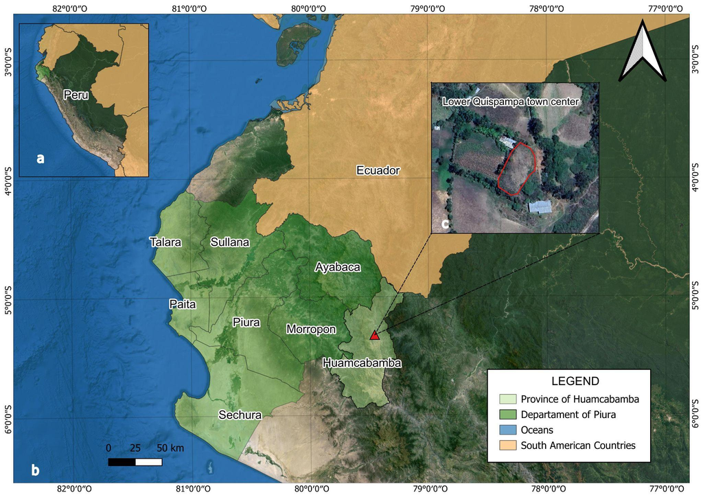

Figure 1: Map showing the location of the study area: (a) Geographic position of the northern Andes of Peru; (b) Location of Huancabamba Province, Piura; (c) Satellite image of the experimental site in Quispampa Bajo.

The soils of Quispampa Bajo are heterogeneous, predominantly of alluvial and colluvial origin, with fertility variations related to topographic slope. Meteorological data – including maximum and minimum air temperature (°C), relative humidity (%), and daily precipitation (mm) – were obtained from the Huancabamba Conventional Meteorological Station (Code 105055) managed by the National Service of Meteorology and Hydrology of Peru (SENAMHI/DRD). During the study period, precipitation ranged from 6.9 mm in October to 150.2 mm in December. Average daily temperatures varied between 13.7 °C (minimum) and 25.7 °C (maximum), with a mean relative humidity of 67.5%. Days were generally warm, providing favorable conditions for the development of *B. cockerelli* populations under natural field exposure.

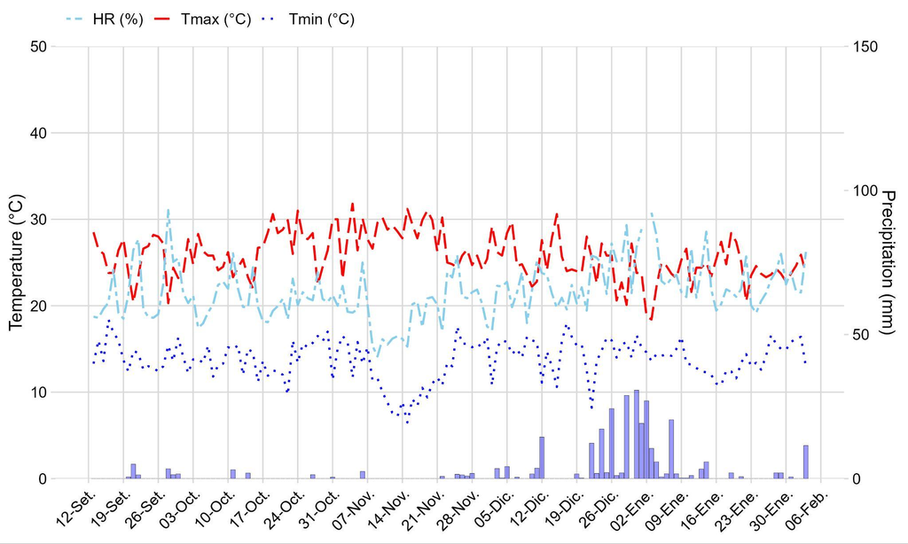

Figure 2: Meteorological data of temperature (°C), precipitation (mm), and relative humidity (%) recorded during the field experiment conducted in the community of Quispampa Bajo, Piura Region, Peru. Maximum and minimum temperature (°C), relative humidity (%), and daily precipitation (mm day⁻¹) data were obtained from the Huancabamba Conventional Meteorological Station (Code 105055) of the National Service of Meteorology and Hydrology of Peru (SENAMHI/DRD), Directorate of Observation Networks and Data.

## 2.2 Target insect

The target insect was the potato psyllid *Bactericera cockerelli* (Šulc) (Hemiptera: Triozidae) [[30]](https://www.zotero.org/google-docs/?5WLFdF), which was first reported in the United States in the 1920s causing yellowing symptoms in potato (*Solanum tuberosum* L.) plants [[31]](https://www.zotero.org/google-docs/?ULEnEk). This psyllid exhibits seven developmental stages: egg, five immature nymphal instars, and the adult stage [[9,13,32]](https://www.zotero.org/google-docs/?4ZIrPv). In this study, the taxonomic identification of *B. cockerelli* was based on morphological traits observed in the egg, nymphal, and adult stages, which, according to previous reports, exhibit limited mobility [[33]](https://www.zotero.org/google-docs/?EUGt0M).

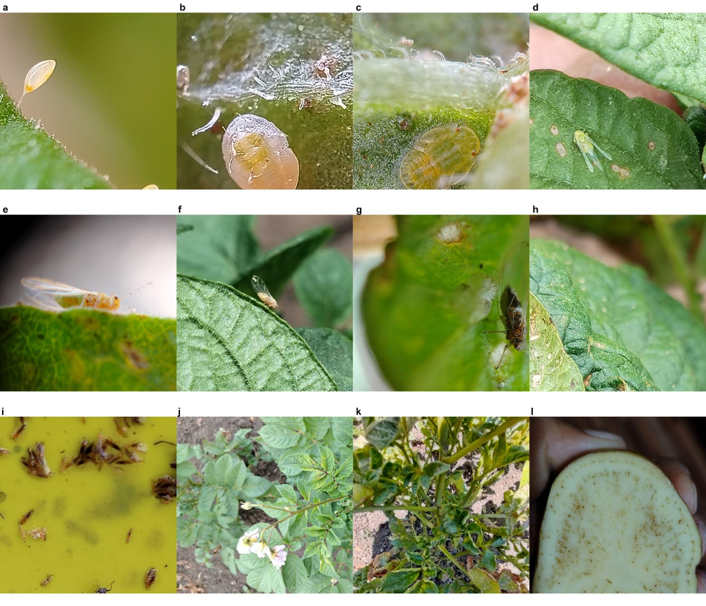

## 2.3 Target crop

The target crop was potato (*Solanum tuberosum* L.; Solanales: Solanaceae), which is commonly affected by the psyllid *Bactericera cockerelli*. The plant material consisted of 400 seed tubers of the variety UNICA (CIP 392797.22), developed by the International Potato Center (CIP, Peru) and released in 1998 [[34]](https://www.zotero.org/google-docs/?nn006u). The seed tubers corresponded to the Pre-Basic Seed Class, as defined in the Specific Potato Seed Regulation of Peru [[35]](https://www.zotero.org/google-docs/?hf9IDF). Planting was performed at a spacing of 0.3 × 1.0 m under field conditions simulating commercial production during the 2024–2025 agricultural season (Figure 4).

The UNICA variety is characterized by slight apical dormancy, with a dormancy period of 40–50 days. It exhibits an early growth cycle, reaching maturity within 70–90 days after sowing (DAS), and may be considered semi-early (90–110 DAS) under low-tropical conditions such as coastal or inter-Andean valleys (0–1500 m a.s.l.). This variety also shows a high yield potential, estimated at 50 t/ha (Gutiérrez-Rosales et al., 2016).

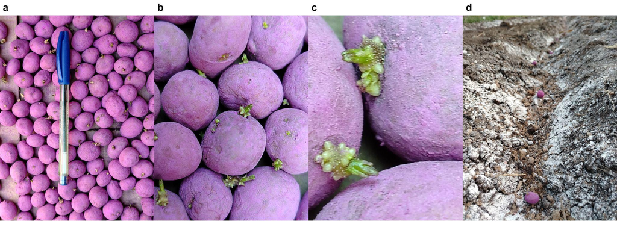

Figure 4: Seed tubers of the potato variety UNICA (CIP 392797.22): (a) pre-basic seed; (b) uniform sprouting; (c) development of sprouts and promising root initials; (d) field planting

## 2.4 Experimental design and treatments

The experiment was established under a randomized complete block design (RCBD) consisting of five treatments with four replications each, totaling 20 experimental units. Each experimental unit comprised 20 potato plants, from which 10 plants located in the second row were selected for evaluation. Treatments were uniformly applied to all plants within each experimental unit.

The evaluated treatments were as follows: untreated control (T0); chemical control – thiamethoxam + lambda-cyhalothrin, abamectin, and imidacloprid (T1); and three commercial biological control agents: *Beauveria bassiana* strain CCB LE-265 (> 1.5 × 10¹⁰ conidia g⁻¹) (T2), *Paecilomyces lilacinus* strain 251 (1.0 × 10¹⁰ conidia g⁻¹) (T3), and *Metarhizium anisopliae* (1.0 × 10¹⁰ conidia g⁻¹) (T4).

Applications were targeted to the egg, nymph, and adult stages of *Bactericera cockerelli.* Spraying commenced once plants reached 98% emergence, approximately 45 days after sowing (DAS), and was performed directly on all aerial plant organs at seven-day intervals. Treatment protocols followed integrated pest and disease management guidelines for potato cultivation [[11,32,36]](https://www.zotero.org/google-docs/?V1S25f).

## 2.5 Application methodology of treatments

The control treatment (T0) consisted solely of water. All other treatments included an agricultural adjuvant composed of 90% soybean oil and 10% emulsifiers at a dose of 5 mL/L, along with a pH regulator applied at 1 mL/L. In addition, a plant growth promoter formulated as a soluble concentrate (SL), containing indole-3-butyric acid (auxin, 2.84 g/L) and 6-benzylaminopurine (cytokinin, 0.02 g/L), was applied at a rate of 500 mL per 200 L of water during the first three spray applications of the crop cycle.

The biological control suspensions were prepared according to the manufacturers’ technical specifications: *Beauveria bassiana* (T2; 200 g per 200 L), *Paecilomyces lilacinus* (T3; 400 g per 200 L), and *Metarhizium anisopliae* (T4; 200 g per 200 L). To enhance fungal effectiveness, a pH regulator (1 mL L⁻¹) and agricultural oil (5 mL L⁻¹) were added to each mixture. The solution was then stirred until fully homogenized and left to rest under shade for 30 min prior to use to preserve conidial viability [[38,39]](https://www.zotero.org/google-docs/?QonY3E). To prevent cross-contamination among the three biological agents, separate sprayer tanks were used for each treatment.

All applications were performed *in situ* under shaded conditions during morning hours at weekly intervals. Manual backpack sprayers equipped with fine-cone nozzles were used to ensure uniform coverage of both adaxial and abaxial leaf surfaces, as well as terminal and lateral shoots and stems [[40]](https://www.zotero.org/google-docs/?gz52l1). **To isolate each treatment, plastic barriers were installed between plots. Each plant surface received three uniform spray passes per application. Afterward, all equipment was thoroughly washed and dried before reuse, following operational protocols to maintain both treatment efficacy and biological agent viability [[41]](https://www.zotero.org/google-docs/?4l5d7N).

## 2.6 Entomological variables and visual inspection methodology for field assessment of *Bactericera cockerelli* life stages

The quantification of *Bactericera cockerelli* presence was conducted using a direct visual inspection method based on systematic field counts. The evaluation consisted of recording the number of eggs, nymphs, and adults on potato plants within each experimental unit through visual sampling of aerial organs. Both the adaxial and abaxial leaf surfaces, stems, petioles, lateral and terminal shoots, and flower calyces were inspected throughout the entire vegetative cycle of the crop, following the protocol established by the International Potato Center, 2022 [[42]](https://www.zotero.org/google-docs/?TCfmMO).

Three entomological variables were assessed: (a) number of eggs, (b) number of nymphs, and (c) number of adults, all identified based on the morphological characteristics of the psyllid on plant foliage [[43]](https://www.zotero.org/google-docs/?dk3uPq). Evaluations were performed weekly between 09:00 and 15:00 h under natural light conditions, four days after treatment application, considering that oviposition typically begins between the fourth and fifth day after adult emergence [[43]](https://www.zotero.org/google-docs/?J9mEhq).

Egg counts of *B. cockerelli* (Šulc) were carried out systematically along leaf margins, followed by detailed examination of both leaf surfaces, leaflets, and secondary branch shoots – preferred oviposition sites for females. The primary morphological diagnostic feature of the egg stage is the pedicel, by which the egg is attached to the plant tissue [[36]](https://www.zotero.org/google-docs/?IgsFsf). This method has proven reliable for detecting and quantifying egg populations under field conditions, providing an accurate estimation of initial infestation density [[42]](https://www.zotero.org/google-docs/?9hN49F).

Nymphal stages were evaluated using a portable entomological magnifier (200×) attached to an Android smartphone camera, enabling in situ identification of first through fifth instar nymphs. Diagnostic morphological features included body size, translucent yellow coloration, and the presence of marginal wax filaments [[36,44]](https://www.zotero.org/google-docs/?TwyBi5)

Adult psyllids were quantified through careful plant inspection, focusing primarily on the upper foliage, where adults typically congregate, particularly during mating or oviposition on young leaves [[36,44]](https://www.zotero.org/google-docs/?D3PVvc). Adults were identified by their distinct morphological traits: an elongated body of dark brown to black color, transparent wings with clear venation, long segmented antennae, and two characteristic whitish abdominal bands [[42,45]](https://www.zotero.org/google-docs/?PgEVgp).

Adult assessments were complemented with an indirect sampling method – yellow sticky traps – following the procedure described by Butler & Trumble (2012) and Cameron et al. (2009) [[36,46]](https://www.zotero.org/google-docs/?axnnHS). The traps were installed around the plot perimeter to monitor population dynamics and weekly fluctuations of the vector in the environment [[25]](https://www.zotero.org/google-docs/?anbOUl). This trapping method is widely used for monitoring sap-sucking pests due to its high efficiency in tracking population trends of hemipteran vectors such as *B. cockerelli* [[33,36,40]](https://www.zotero.org/google-docs/?g1MRW0).

A total of twelve rectangular traps (40 × 25 cm per side) were used, each coated on both surfaces with a commercial entomological adhesive [[25]](https://www.zotero.org/google-docs/?KA0OwV). The traps were fixed to support structures at two heights: 15 cm above the ground level from planting to hilling, and 30 cm thereafter until harvest, following population dynamics criteria reported in previous studies [[44]](https://www.zotero.org/google-docs/?HMh1E6). Traps were replaced weekly after counting the captured adults. This approach enabled continuous recording of vector population fluctuations, complementing direct plant evaluations and providing a reliable indicator of psyllid pressure within the agroecosystem [[45]](https://www.zotero.org/google-docs/?DtlGt3). Data on adult captures from yellow traps are presented in Supplementary Table 1.

## 2.7 Agronomic variables

The agronomic variables evaluated were yield (g/plant) and number of tubers per plant. Yield was quantified as the total fresh weight of tubers obtained per plant, expressed in grams, using a precision balance (T-Scale TB, capacity 3000 g, accuracy 0.1 g). The number of tubers per plant was determined through direct counting of each experimental plant sample.

Both variables were assessed following the standard procedures for potato yield trials described by De Haan et al. (2014) at the International Potato Center (CIP) [[47]](https://www.zotero.org/google-docs/?MaC18N). This protocol involves the individual harvesting of experimental plants, followed by tuber counting and weighing with a precision balance. The method provides reliable estimations of yield parameters under field conditions.

## 2.8 Methodology for the diagnosis of the purple-top complex and zebra chip disease

The presence of purple-top symptoms and the incidence of zebra chip disease were assessed in the laboratory, both conditions being associated with infection by *Candidatus Liberibacter solanacearum* transmitted by *Bactericera cockerelli* [[45]](https://www.zotero.org/google-docs/?CtCdZP).

To diagnose the presence of purple-top symptoms in potato plants, a binary categorical scale was used, where 0 = absence and 1 = presence, following the qualitative nature of the variable. This approach has been previously applied to identify phytoplasma-associated symptoms in potato and other crops, allowing accurate recording of disease incidence. Morphological characterization of symptoms associated with the purple-top complex included apical yellowing, foliar reddening or purpling, chlorotic apical growth, leaf curling, stunting, leaf deformation, formation of aerial tubers, and vascular necrosis in tubers [[45,48]](https://www.zotero.org/google-docs/?pbuAW1).

The incidence (%) of zebra chip disease in potato tubers was evaluated using the fresh tuber cross-section method described by Munyaneza (2012) [[45]](https://www.zotero.org/google-docs/?HWWLFY). Each harvested tuber from evaluated plants was transversely cut and visually inspected for characteristic symptoms, particularly dark brown to black necrotic streaks in the medullary tissue. The incidence percentage was subsequently calculated using the formula proposed by [[49]](https://www.zotero.org/google-docs/?WLNIuz), commonly employed in epidemiological studies to quantify disease incidence and severity. This method enables the morphological characterization of zebra chip symptomatology in potato tubers caused by *Candidatus Liberibacter solanacearum* [[45,48]](https://www.zotero.org/google-docs/?N98MgR).

$$Incident_{zebra\ chip}\left(\%\right)\ =\left(\frac{Number\ of\ tubers\ with\ necrotic\ streaks\ in\ medulla}{Total\ number\ of\ tubers\ sampled}\right)\cdot100$$

## 2.9 Statistical analysis

All statistical analyses were performed using R software, version 4.5.1 [[50]](https://www.zotero.org/google-docs/?hhdlOG). For count-type response variables, generalized linear models (GLMs) with a Poisson distribution were fitted. In cases where overdispersion was detected, a quasi-Poisson distribution was applied to obtain more robust estimates [[51]](https://www.zotero.org/google-docs/?aG328R). Binary variables (presence/absence) were analyzed using GLMs with a binomial distribution. For continuous variables, linear mixed-effects models (LMMs) were applied using the lme4 package [[52]](https://www.zotero.org/google-docs/?JhkszG), which allows for the inclusion of both fixed and random effects, improving the capacity to model dependent data and address potential violations of normality and homoscedasticity assumptions [[53]](https://www.zotero.org/google-docs/?RuEaKS). Model significance was assessed using analysis of variance (ANOVA), and multiple mean comparisons were conducted with Tukey’s Honestly Significant Difference (HSD) test at a significance level of α = 0.05, implemented through the emmeans package **[[54]](https://www.zotero.org/google-docs/?0X32pi).

# 3 RESULTS

## 3.1 Insect behavior

To evaluate the effect of biological and chemical treatments on psyllid population dynamics, the presence of *Bactericera cockerelli* (Šulc) in its three developmental stages (egg, nymph, and adult) was monitored in the aerial organs of *Solanum tuberosum* L. var. UNICA through direct visual inspection and insect counts throughout the entire phenological cycle of the crop.

A total of 2,000 adult psyllids were captured across the 12 weekly yellow traps over 16 weeks, providing consistent evidence of adult vector activity in the experimental field. Detailed trap data are presented in the Electronic Supplementary Material (ESM).

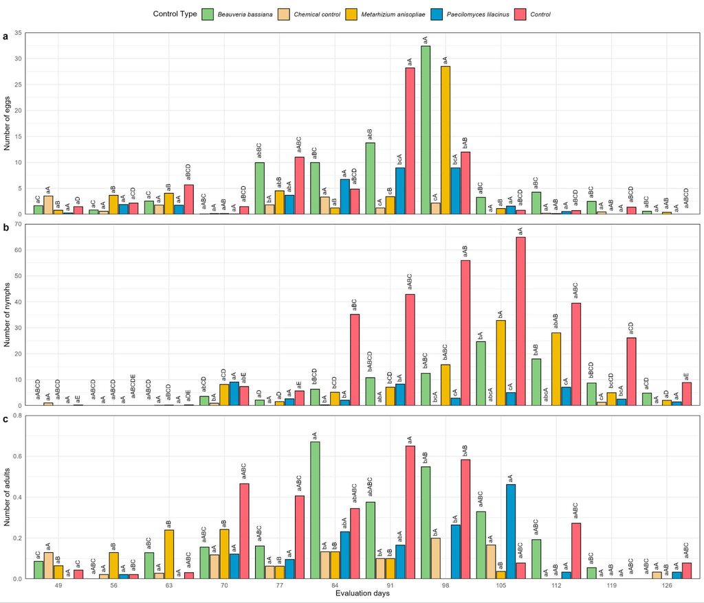

Figure 5: Evaluation of the pest insect *Bactericera cockerelli* at its three developmental stages, monitored weekly on the foliar area of potato plants under field conditions in Quispampa Bajo, Huancabamba Province, Piura, Peru. (a) number of eggs, (b) number of nymphs, and (c) number of adults.

## 3.2 Symptomatology of purple-top complex in plants and zebra chip disease in potato tubers

To assess the effect of biological and chemical treatments on the expression of purple-top symptoms in potato (*Solanum tuberosum* L.) var. UNICA under field conditions, the probability of incidence of the purple-top complex and the presence of zebra chip (ZC) were evaluated. The incidence of purple-top was determined based on morphological characteristics observed in the plants, whereas zebra chip incidence was assessed in tubers according to the presence of characteristic necrotic streaks [[45,48]](https://www.zotero.org/google-docs/?ulIfiO).

The results showed that the application of treatments produced significant differences (p < 0.05) in the probability of purple-top complex occurrence (Figure 6a). The chemical control (T1) exhibited the lowest probability of symptom presence (0.46), significantly lower than T0 (0.91) and T2 (0.83). Likewise, *Metarhizium anisopliae* (T4) showed a lower probability of occurrence (0.49) compared to T0, T2, and T3, although it differed statistically only from the untreated control (T0).

In contrast, no significant differences (p = 0.778) were observed among treatments for the incidence rate of zebra chip in tubers (Figure 6b). Despite the lack of statistical differences, treatment T4 exhibited the lowest incidence rate (56.60%), while the highest incidence was recorded in the untreated control (T0) with 68.61%.

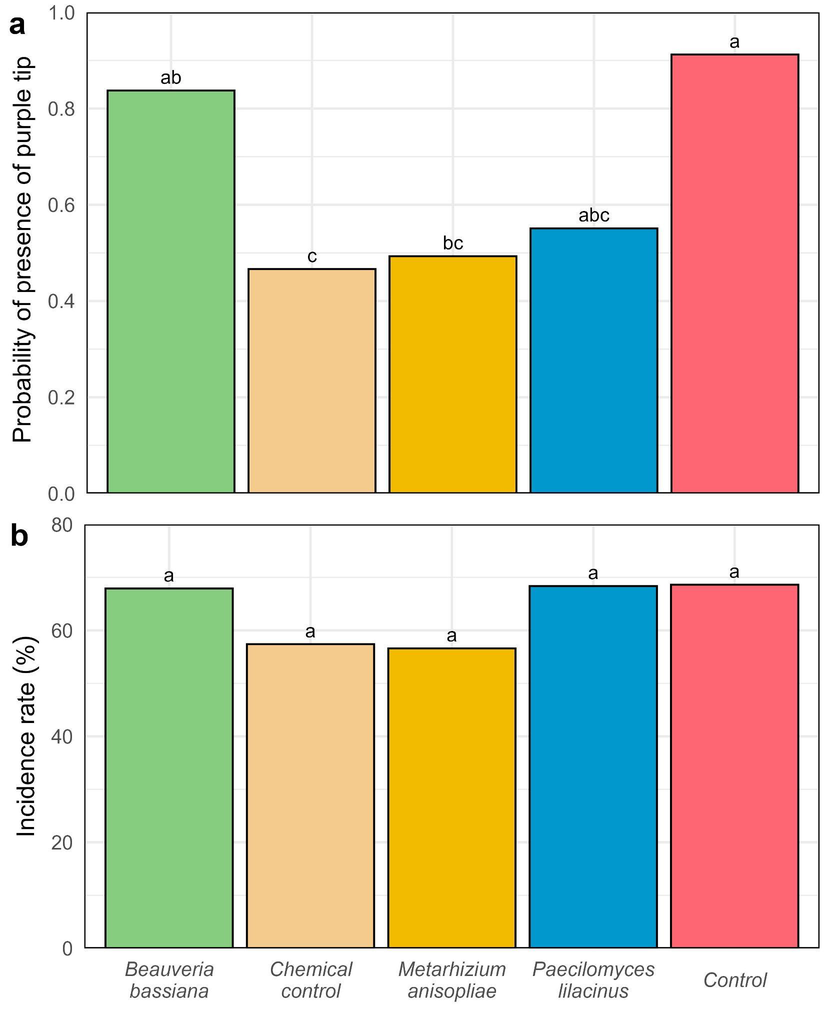

Figure 6: Evaluation of purple-top symptomatology in potato plants during the flowering stage and incidence of zebra chip disease in tubers of the UNICA variety (CIP 392797.22). Symptoms were identified based on morphological characteristics, including brown splinter-like streaks observed after transverse cutting of harvested tubers. (a) Probability of purple-top occurrence in plants; (b) incidence rate of zebra chip disease (%).

## 3.3 Agronomic response of potato crop under the presence of *Bactericera cockerelli*

To evaluate the effect of biological and chemical treatments on the yield performance of potato (*Solanum tuberosum* L.) var. UNICA under field conditions, the number of tubers per plant and fresh tuber weight were determined. Measurements followed the methodology established by the International Potato Center (CIP), which enables the estimation of yield parameters under field conditions while distinguishing treatment effects from environmental influences on crop productivity [[47]](https://www.zotero.org/google-docs/?BNuvXj).

The results showed that the application of treatments produced significant differences (p < 0.05) in tuber fresh weight per plant (Figure 7a). The chemical control (T1) exhibited the highest tuber weight, averaging 198.86 g plant⁻¹, significantly exceeding T0 (32.63 g) and T2 (86.93 g). Similarly, *Paecilomyces lilacinus* (T3) and *Metarhizium anisopliae* (T4) significantly outperformed the untreated control (T0), with mean tuber weights of 120.41 g and 122.84 g, respectively.

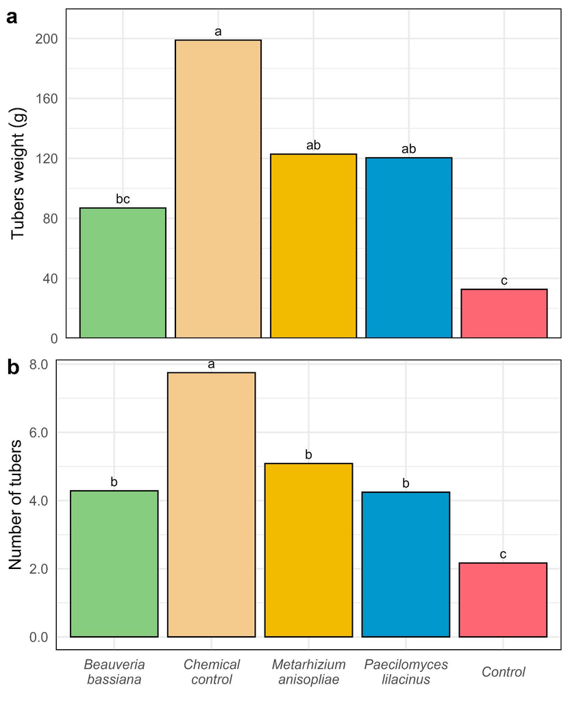

Figure 7: Agronomic variables evaluated in the potato variety UNICA exposed to infestation by the psyllid Bactericera cockerelli, the vector of *Candidatus Liberibacter solanacearum*, under field conditions: (a) tuber fresh weight per plant (g) and (b) number of tubers per plant.

# 4 DISCUSSION

This study evaluated the occurrence of the invasive pest *Bactericera cockerell*i (Šulc) in potato crops in the northern highlands of Peru, the probability of purple-top symptom expression, the incidence rate of zebra chip disease, and the agronomic performance of *Solanum tuberosum* L. var. UNICA under field conditions. The results demonstrated the differential effects of chemical control (T1) and biological agents (T2, T3, T4) on the pest–disease complex, providing insight into their efficacy, limitations, and potential for integration into sustainable management strategies for potato cultivation under field conditions.

## 4.1 Insect behavior

The results obtained for the number of *Bactericera cockerelli* eggs indicate that the evaluated treatments exerted differential effects throughout the phenological cycle of Solanum tuberosum. The higher initial efficacy observed with the chemical control (T1) at 77 days after installation, compared with the untreated control (T0), can be attributed to the complementary modes of action of thiamethoxam (a systemic neonicotinoid), lambda-cyhalothrin (a contact pyrethroid), and abamectin (a translaminar avermectin). These compounds interfere with feeding behavior and neural signal transmission in hemipterans, thus reducing oviposition rates [[55]](https://www.zotero.org/google-docs/?jchZwv). Similar findings were reported by Yang et al. (2010) [[44]](https://www.zotero.org/google-docs/?tl5Zfr), who demonstrated that insecticidal treatments can suppress female feeding activity and consequently decrease egg deposition. This combined effect is consistent with studies in which sequential applications of systemic and contact insecticides resulted in rapid suppression of *B. cockerelli* populations at early developmental stages [[17]](https://www.zotero.org/google-docs/?Vpc2xF). At 91 days, the superior performance of *Metarhizium anisopliae* (T4) and chemical control (T1) compared with *Beauveria bassiana* (T2) and the control (T0) suggests greater adaptability of *M. anisopliae* to local environmental conditions. This entomopathogenic fungus demonstrates optimal germination and virulence in climates with temperatures ranging from 25 to 28 °C and relative humidity between 65–75%, conditions that match those recorded in Quispampa Bajo [[56]](https://www.zotero.org/google-docs/?7OqAep). In contrast, *B. bassiana* tends to exhibit reduced persistence under high solar radiation, which may decrease its medium-term efficacy [[56]](https://www.zotero.org/google-docs/?sJVKJw). At 98 days, *Paecilomyces lilacinus* (T3) showed efficacy comparable to the chemical control (T1), a noteworthy finding considering that *P. lilacinus* is primarily a nematophagous fungus, and its application in *B. cockerelli* management remains relatively novel.

During the nymphal stage, although the chemical treatment (T1) exhibited an initial advantage, all treatments eventually outperformed the untreated control, suggesting that the interaction between field water stress and biological agents may have limited nymphal development [[21]](https://www.zotero.org/google-docs/?GDnhnI). This pattern aligns with the findings of Harrison et al. (2021) [[57]](https://www.zotero.org/google-docs/?I1PPHS), who reported that abiotic stress can reduce the developmental rate of *Bactericera cockerelli* by altering the composition of phloem sap. The efficacy of *Paecilomyces lilacinus* (T3) may be attributed to its ability to colonize plant tissues, which likely allowed it to affect immature nymphal stages internally, thereby explaining the sustained suppression of nymph populations observed in this study. Moreover, studies such as that of Athanassiou et al. (2017) [[58]](https://www.zotero.org/google-docs/?VHEdlN) have confirmed that *Metarhizium anisopliae* (T4) remains effective against sap-sucking insects even under conditions of low relative humidity, owing to its capacity to persist within the microclimate of the plant canopy.

Overall, the chemical control (T1) maintained superior efficacy at key points of the crop cycle, largely due to the rotational use of active ingredients, and significantly outperformed most biological treatments. However, the findings of this study also support the potential of *Paecilomyces lilacinus* (T3) as a viable alternative to chemical control, particularly under field conditions characterized by water stress. These results reinforce the importance of developing integrated pest management (IPM) strategies that combine insecticide rotation with the application of fungal-based biological agents, optimizing application timing according to climatic conditions and pest phenology. Similarly, Lacey et al. (2011) [[40]](https://www.zotero.org/google-docs/?xA8Z6I) demonstrated that the integration of biological and chemical control can enhance suppression of *B. cockerelli* populations without increasing resistance selection pressure. Such integration can reduce dependence on broad-spectrum insecticides, mitigate the risk of resistance development, and sustain long-term control efficacy in potato production systems affected by *B. cockerelli* [[17]](https://www.zotero.org/google-docs/?KwjsZt).

## 4.2 Symptomatology of purple-top complex in plants and zebra chip in potato tubers

The analysis of the probability of purple-top complex occurrence revealed significant differences among treatments, with the chemical control (T1) exhibiting the lowest value (0.46). Since values closer to zero indicate the absence of symptom expression, this result reflects a reduced likelihood of symptom development compared with the untreated control (T0) and *Beauveria bassiana* (T2). This suggests that the mode of action of T1 – whether chemical or due to the synergistic combination of its active ingredients – was more effective in reducing the activity of the vector *Bactericera cockerelli* or in limiting the expression of purple-top complex symptoms. Previous studies have demonstrated that a reduction in infection probability can be associated with interference in the feeding behavior of *B. cockerelli* and a consequent decrease in the transmission rate of *Candidatus Liberibacter solanacearum* between the host plant and the vector [[11,61]](https://www.zotero.org/google-docs/?5Fhgs9).

Regarding disease incidence, no significant differences were detected among treatments (p = 0.778). However, *Metarhizium anisopliae* (T4) exhibited the lowest incidence rate (56.60%) compared with the other treatments, which presented higher percentages and, consequently, a greater risk of zebra chip symptom expression in tubers. Although this difference was not statistically significant, it may hold agronomic relevance, as values approaching 100% indicate a high probability of visible damage and significant losses in commercial quality [[36]](https://www.zotero.org/google-docs/?ULl1Px). Additionally, Stoop et al. (2009) [[62]](https://www.zotero.org/google-docs/?2jVOxd) noted that, under field conditions, environmental variability can often mask statistical effects, even when the agronomic impacts are evident to growers.

The joint interpretation of the probability of purple-top complex occurrence and the incidence rate of zebra chip (ZC) suggests that the chemical control (T1) is the most promising treatment for reducing the likelihood of purple-top symptom expression, whereas *Metarhizium anisopliae* (T4) may contribute to lowering the incidence of tuber symptoms. Similar results were reported by Greenway & Rondon (2018) [[37]](https://www.zotero.org/google-docs/?t0gEjD), who emphasized that even in the absence of statistical significance, consistent reductions observed under field conditions can be highly relevant for integrated pest management (IPM) programs.

These findings are critical for field-level decision-making: low values of probability and incidence represent a reduced phytosanitary and economic risk, whereas high values indicate the need for immediate implementation of control measures. It is worth highlighting that *Bactericera cockerelli* (Šulc) is the primary vector responsible for transmitting *Candidatus Liberibacter solanacearum* (CLso), the etiological agent associated with zebra chip disease, as documented in studies conducted in other regions of North America and Europe [[14,32]](https://www.zotero.org/google-docs/?0qKtUF).